# ggplot2 presentation

Yuan Li

2023-10-09

```r
knitr::opts_knit$set(root.dir = "C:/Users/YUAN LI/Desktop/ggplot2_example_data/")
getwd()
```

```
## [1] "C:/Users/YUAN LI/Desktop"
```

```r
library(readxl)
library(tidyverse)
library(lubridate)
library(ggplot2)
```

# ggplot2

**Data**

This is a dataset on Lyme disease from [Project Tycho](https://www.tycho.pitt.edu/), a website that aggregates disease data over time and geography. This dataset collects the occurrence of Lyme disease from 1990 to 2016 across the United States.

```r
annual_counts <- read_csv("Lymes.csv",
                          col_type=cols(PartOfCumulativeCountSeries = col_logical())) %>%
  filter(PartOfCumulativeCountSeries) %>%
  mutate(year = year(PeriodStartDate+7)) %>%
  group_by(year) %>%
  summarize(count = max(CountValue))
```

This is a PCoA analysis data the Bray-Curtis distances of the microbiome between stool samples collected from patients with different diagnosis.

```r
pcoa <- read_tsv(file="baxter.braycurtis.pcoa.axes")
metadata <- read_excel(path="baxter.metadata.xlsx")
metadata_pcoa <- inner_join(metadata, pcoa, by=c('sample'='group'))
```

```r
meta_alpha <- read_csv("meta.alpha.csv")
```

## Layers

ggplot2 uses the idea of “layers” and the operator $+$ to add layers:

**Coordinates and variables**

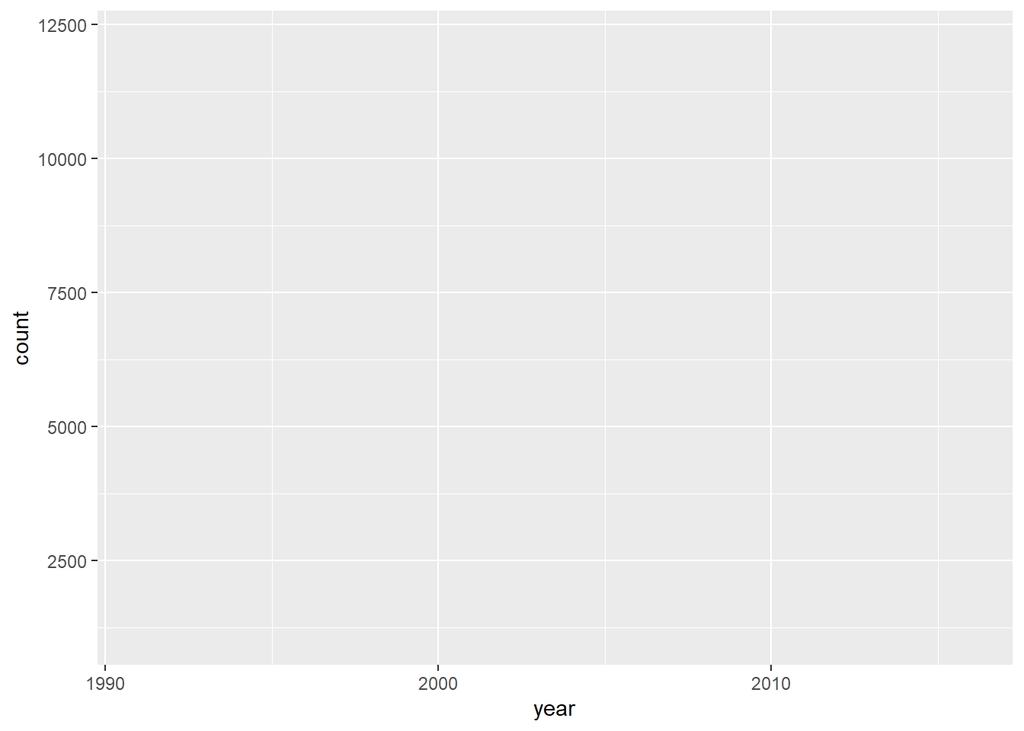

```r
ggplot(annual_counts, aes(x=year, y=count))
```

**Plotting type**

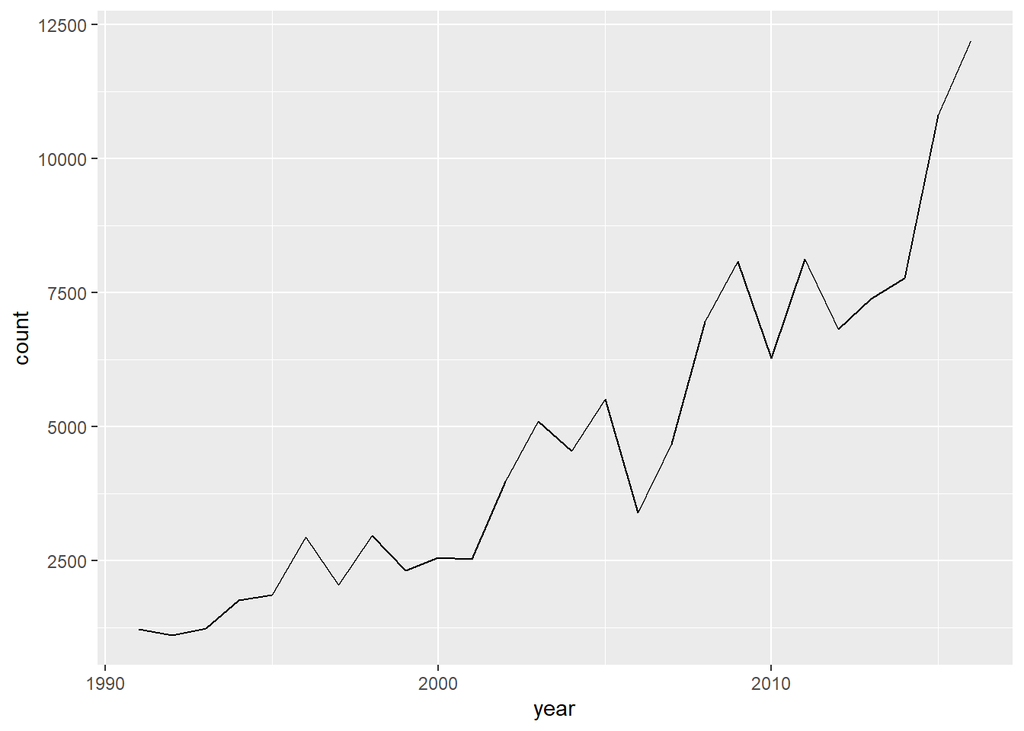

```r
ggplot(annual_counts, aes(x=year, y=count)) +
  geom_line()
```

**Each type of plotting is a new layer:**

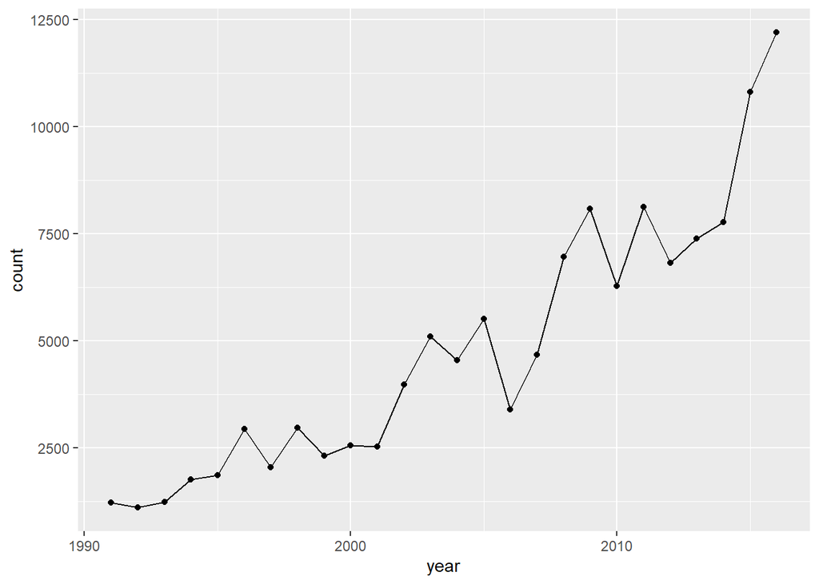

```r
ggplot(annual_counts, aes(x=year, y=count)) +
    geom_line() +
    geom_point()
```

## Aesthetics

From my experience, the most frequently used and helpful arguments for adjusting the labels and axes are:

- **scale_x_continuous()**: can specify range, break, and how tick labels are shown
- **scale_y_continuous()**
- **labs()**: easiest way to set x, y, and main titles
- **scale_color_manual()**: can specify colors and how legend is shown with great freedom

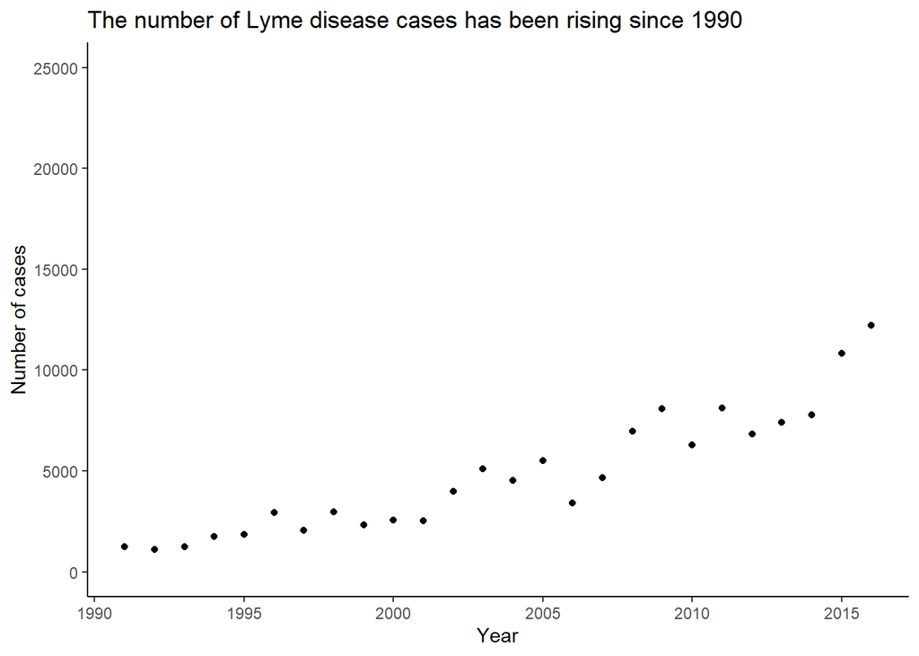

```r
ggplot(annual_counts, aes(x=year, y=count)) +
    geom_point() +
    scale_y_continuous(limits=c(0,25000)) +
    scale_x_continuous(breaks=c(1990, 1995, 2000, 2005, 2010, 2015)) +
    labs(x="Year",
         y="Number of cases",
         title="The number of Lyme disease cases has been rising since 1990") +
    theme_classic()
```

You can show tick labels differently than the actual data:

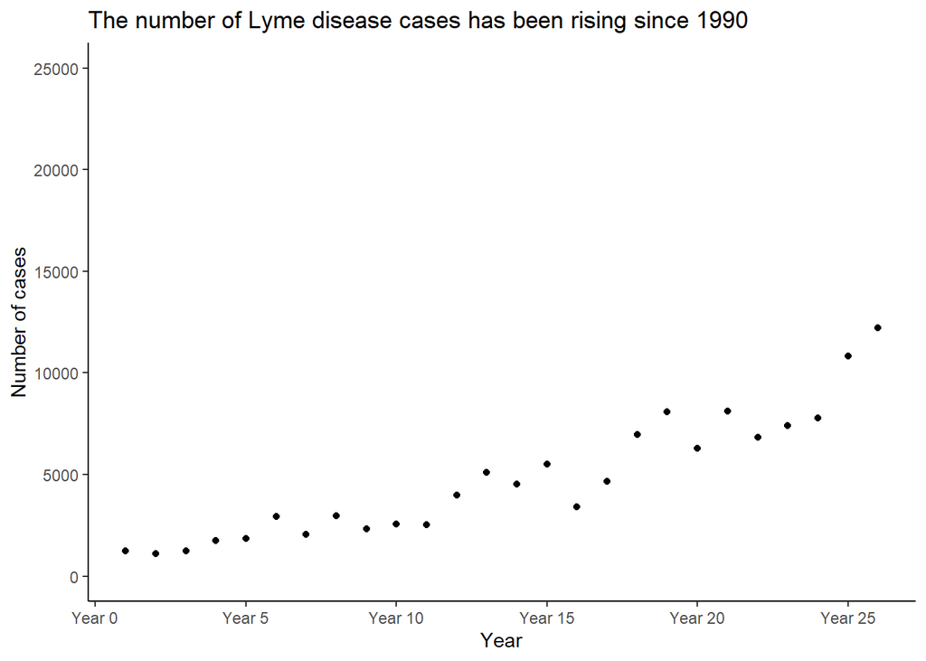

```r
ggplot(annual_counts, aes(x=year, y=count)) +
    geom_point() +
    scale_y_continuous(limits=c(0,25000)) +
    scale_x_continuous(breaks=c(1990, 1995, 2000, 2005, 2010, 2015),
                       label = c("Year 0", "Year 5", "Year 10",
                                 "Year 15", "Year 20", "Year 25")) +
    labs(x="Year",
         y="Number of cases",
         title="The number of Lyme disease cases has been rising since 1990") +
    theme_classic()
```

You can use scientific notation:

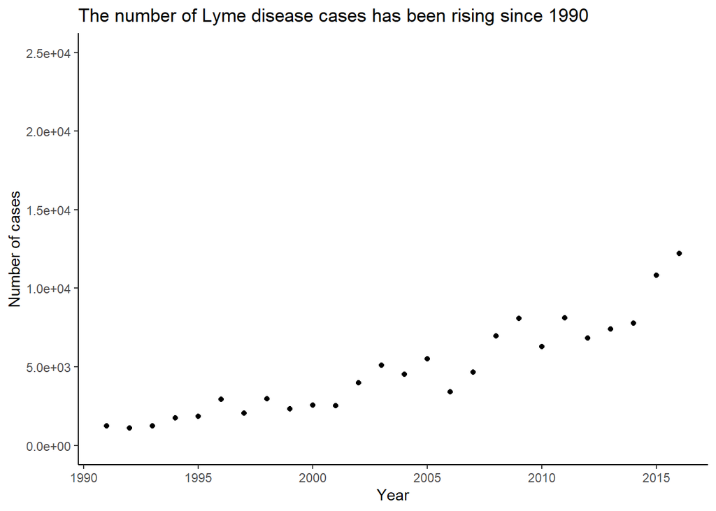

```r
ggplot(annual_counts, aes(x=year, y=count)) +
    geom_point() +
    scale_y_continuous(limits=c(0,25000),
                       labels = scales::scientific) +
    scale_x_continuous(breaks=c(1990, 1995, 2000, 2005, 2010, 2015)) +
    labs(x="Year",
         y="Number of cases",
         title="The number of Lyme disease cases has been rising since 1990") +
    theme_classic()
```

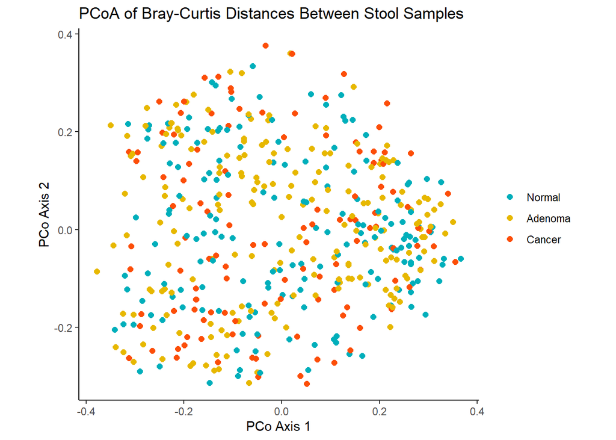

```r
ggplot(metadata_pcoa, aes(x=axis1, y=axis2, color=dx)) +
    geom_point(shape=19, size=2) +
    scale_color_manual(name=NULL,
        values=c("#00AFBB", "#E7B800", "#FC4E07"),
        breaks=c("normal", "adenoma", "cancer"),
        labels=c("Normal", "Adenoma", "Cancer")) +
    coord_fixed() +
    labs(title="PCoA of Bray-Curtis Distances Between Stool Samples",
        x="PCo Axis 1",
        y="PCo Axis 2") +
    theme_classic()
```

## Significance

One thing I don’t like about ggplot2 is that the significance needs to be calculated beforehand and added as a drawing when the statistics is slightly complicated:

The csv ‘meta_alpha’ is a simpified metadata file from ‘metadata’. The plots below show the relationship between colorectal cancer screening diagnosis and the faecal immunochemical testing (FIT) result:

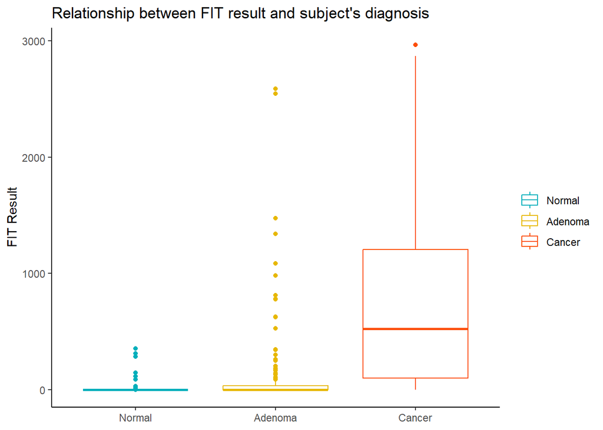

```r
meta_alpha_box <-
  ggplot(meta_alpha, aes(x=diagnosis, y=fit_result, color=diagnosis)) +
    geom_boxplot() +
    scale_color_manual(name=NULL,
        values=c("#00AFBB", "#E7B800", "#FC4E07"),
        breaks=c("normal", "adenoma", "cancer"),
        labels=c("Normal", "Adenoma", "Cancer")) +
    scale_x_discrete(limits=c("normal", "adenoma", "cancer"),
        labels=c("Normal", "Adenoma", "Cancer")) +
    labs(title="Relationship between FIT result and subject's diagnosis",
        x=NULL,
        y="FIT Result") +
    theme_classic()

meta_alpha_box
```

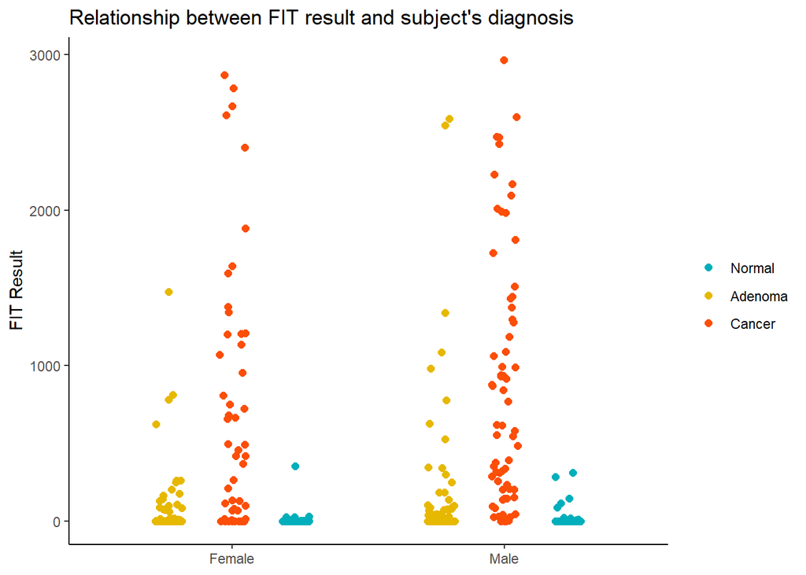

```r
meta_alpha_jitter <-
  ggplot(meta_alpha, aes(x=sex, y=fit_result, color=diagnosis)) +
    geom_jitter(shape=19, size=2, position=position_jitterdodge(dodge.width=0.7, jitter.width=0.1)) +
    scale_color_manual(name=NULL,
        values=c("#00AFBB", "#E7B800", "#FC4E07"),
        breaks=c("normal", "adenoma", "cancer"),
        labels=c("Normal", "Adenoma", "Cancer")) +
    scale_x_discrete(limits=c("female", "male"),
        labels=c("Female", "Male")) +
    labs(title="Relationship between FIT result and subject's diagnosis",
        x=NULL,
        y="FIT Result") +
    theme_classic()

meta_alpha_jitter
```

Package [ggpubr](https://rpkgs.datanovia.com/ggpubr/) can help:

- **compare_means()**: to performs one and multiple mean comparisons.
- **stat_compare_means()**: to automatically add p-values and significance levels to a ggplot.

To add p-values between groups, you need to specify the comparisons you want:

```r
library(ggpubr)

compare_means(fit_result~diagnosis, data=meta_alpha, method = "t.test", paired = FALSE)
```

```
## # A tibble: 3 x 8
##   .y.        group1  group2         p    p.adj p.format p.signif method
##   <chr>      <chr>   <chr>      <dbl>    <dbl> <chr>    <chr>    <chr>
## 1 fit_result normal  adenoma 1.84e- 4 1.8 e- 4 0.00018  ***      T-test
## 2 fit_result normal  cancer  1.20e-18 3.60e-18 < 2e-16  ****     T-test
## 3 fit_result adenoma cancer  2.82e-15 5.6 e-15 2.8e-15  ****     T-test
```

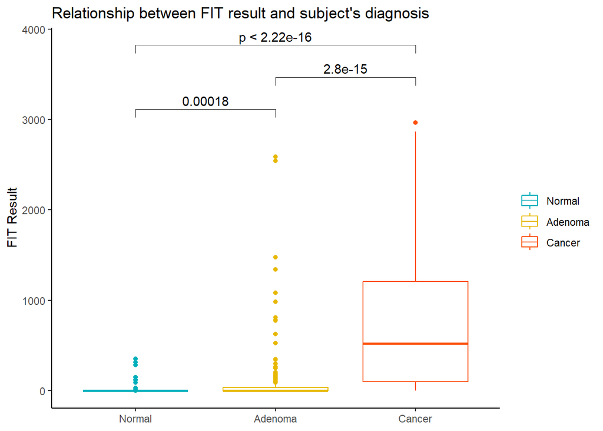

```r
comparisons <- list( c("normal", "adenoma"),
                        c("adenoma", "cancer"),
                        c("normal", "cancer") )

meta_alpha_box +
  stat_compare_means(comparisons = comparisons, method = "t.test")
```

Adding significance values is still easy when you use facet:

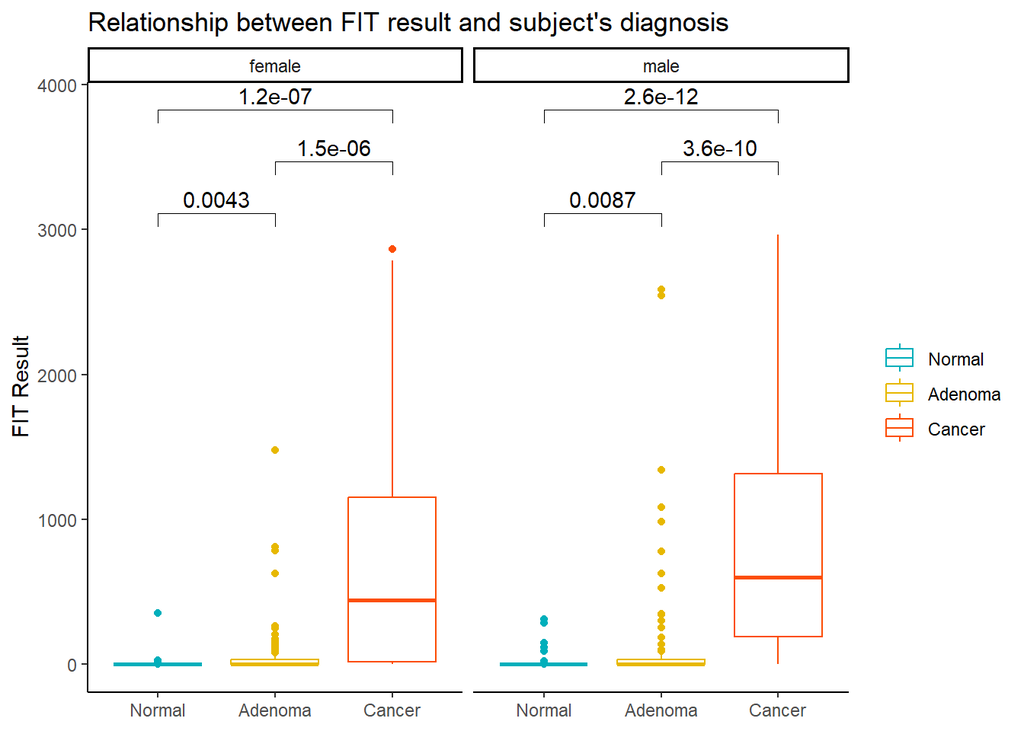

```r
meta_alpha_boxplot_facet <-
  ggplot(meta_alpha, aes(x=diagnosis, y=fit_result, color=diagnosis)) +
    geom_boxplot() +
  facet_wrap(~sex) +
    scale_color_manual(name=NULL,
        values=c("#00AFBB", "#E7B800", "#FC4E07"),
        breaks=c("normal", "adenoma", "cancer"),
        labels=c("Normal", "Adenoma", "Cancer")) +
    scale_x_discrete(limits=c("normal", "adenoma", "cancer"),
        labels=c("Normal", "Adenoma", "Cancer")) +
    labs(title="Relationship between FIT result and subject's diagnosis",
        x=NULL,
        y="FIT Result") +
    theme_classic()

meta_alpha_boxplot_facet +
  stat_compare_means(comparisons = comparisons, method = "t.test", aes(group = sex))
```

But it you want to compare while having groups, and at the same time don’t want to use `facet_wrap()`, you need to create another variable in the dataset and make new comparisons.

## Ordering

Package [forcats](https://forcats.tidyverse.org/) is very helpful when you want to put categorical variables in a specific order:

- **fct_reorder()**: reordering a factor by another variable.
- **fct_infreq()**: reordering a factor by the frequency of values.
- **fct_relevel()**: changing the order of a factor by hand.

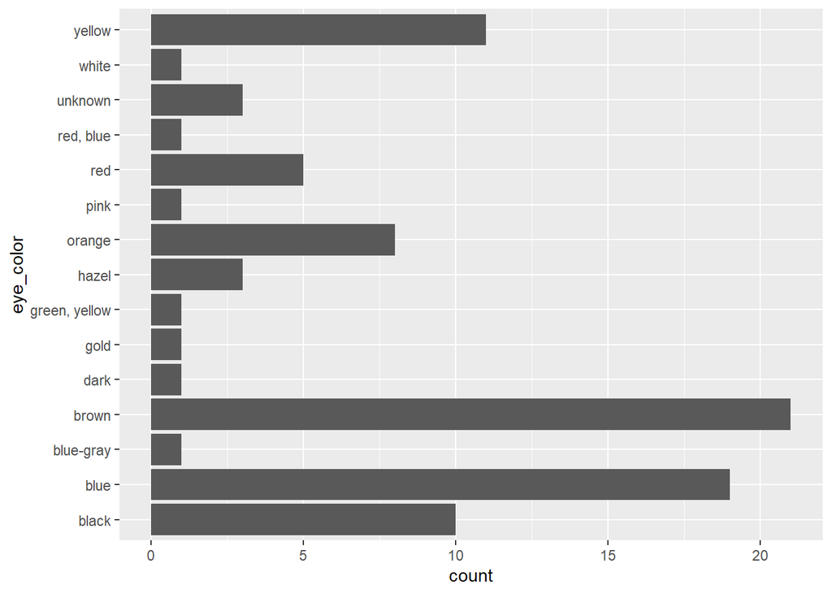

```r
library(forcats)

ggplot(starwars, aes(x = eye_color)) +
  geom_bar() +
  coord_flip()
```

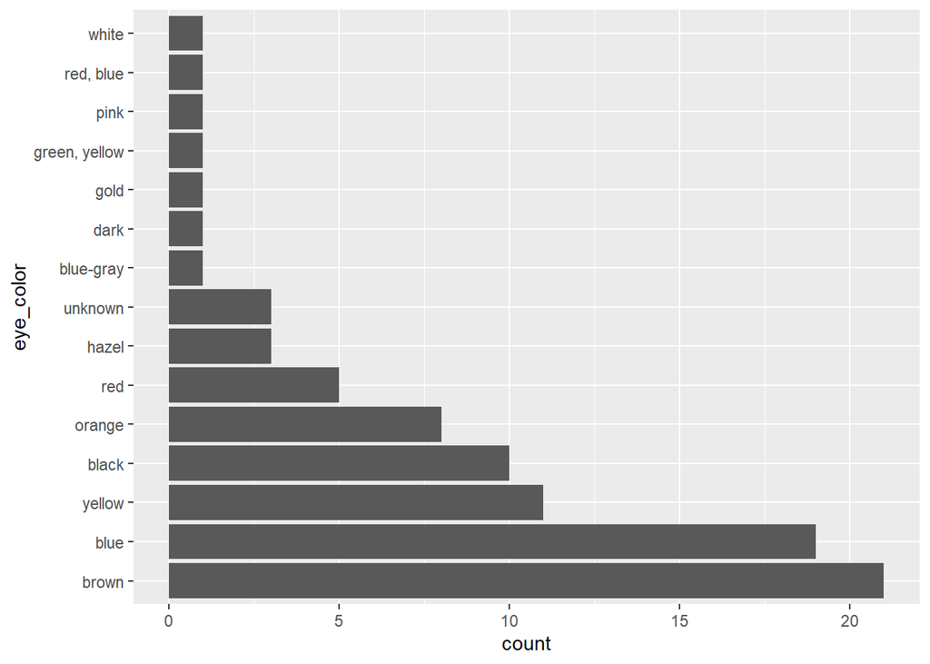

```r
starwars %>%
  mutate(eye_color = fct_infreq(eye_color)) %>%
  ggplot(aes(x = eye_color)) +
  geom_bar() +
  coord_flip()
```

## Arrangement

Sometimes you would want to arrange multiple plots in one figure, and the plots don’t always fit into a grid. I found packages [patchwork](https://patchwork.data-imaginist.com/) and [ggarrange](https://rpkgs.datanovia.com/ggpubr/reference/ggarrange.html) useful. I would try *patchwork* first, as it is better maintained, and use *ggarrange* if *patchwork* doesn’t work.

You can freely [define the layout](https://patchwork.data-imaginist.com/articles/guides/layout.html), including blank spaces.

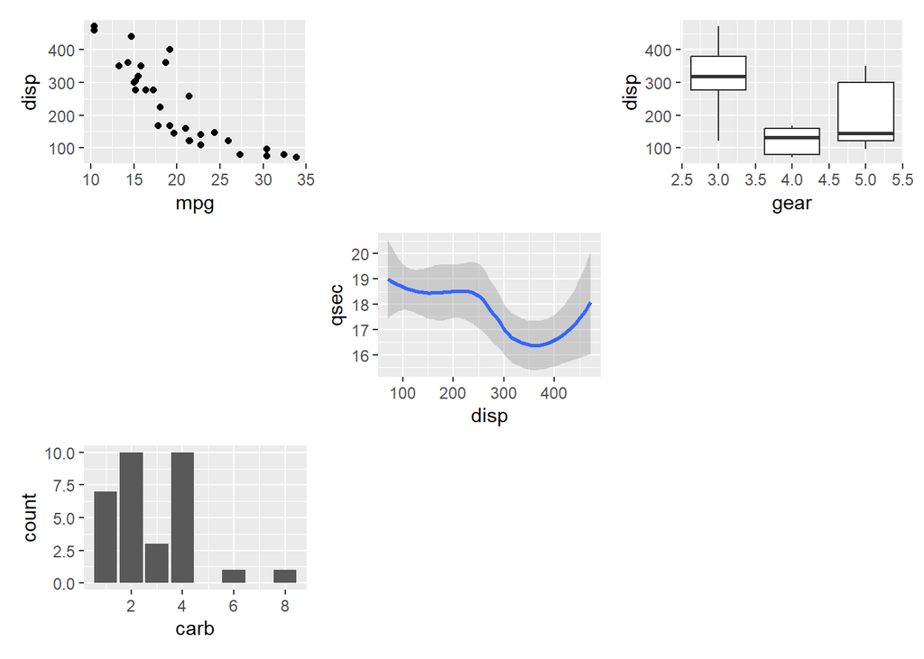

```r
library(patchwork)

p1 <- ggplot(mtcars) + geom_point(aes(mpg, disp))
p2 <- ggplot(mtcars) + geom_boxplot(aes(gear, disp, group = gear))
p3 <- ggplot(mtcars) + geom_smooth(aes(disp, qsec))
p4 <- ggplot(mtcars) + geom_bar(aes(carb))

layout <- '
A#B
#C#
D#E
'
wrap_plots(A = p1, B = p2, C = p3, D = p4, design = layout)
```

## Exporting figures

Journals have specific requirements on figures, including fonts, font size, theme styles, colors, etc. It would be easier to have a global setting before exporting figures for publications.

```r
# pdf("Fig.2b.diversity.decrease.pdf", onefile = TRUE, bg = "white",
#     family = font, width = fig_wid_half, height = 5) # device pdf uses ArialMT for Arial
#
# theme_set(theme_bw(base_size = fz_general))
# theme_update(axis.text = element_text(size = fz_axis_tick),
#              axis.title = element_text(size = fz_axis_title),
#              strip.text = element_text(size = fz_panel_title, face = "bold"))
#
# print(codon_decrease / aa_decrease)
#
# invisible(dev.off())
```